# Final Project

Stephen Curry's Impact on the Game of Basketball

by Joseph Schoenbaum

Introduction: It's a general agreement in the basketball community that Stephen Curry is the greatest shooter of all time. Just this week, Damian Lillard, who many consider the current 2nd best shooter in the world behind Curry, stated, “Steph is right behind Magic (highly regarded as the best point guard to ever play an NBA game) in the way he has changed the game and the excitement with his style of play”. That is incredible respect from one of Curry's main rivals in the NBA. In mainstream media, it seems as if everyone agrees Curry is a great player, but people don't seem to give him the credit for how much he has impacted the NBA game. An NBA game played in 2010 looks like a completely different sport compared to an NBA game played today. Sure, you can spit out Curry's points per game average, his NBA all-time free throw percentage (90.7%), or his 3 championships, but those are elementary statistics that only show a sliver of Curry's impact. I want to help people better understand the game of basketball, and I'm going to do my best to portray why I believe Stephen Curry is one of the most influential players to steph (haha see what I did there) foot onto an NBA court.

```python
#We will start by importing the libraries necessary to do the analysis
import requests as req
from bs4 import BeautifulSoup
import pandas as pd
import numpy as np
import matplotlib.pyplot as plt
import statsmodels.formula.api as sm
from sklearn import linear_model
```

Source: The website I will be gathering data from is called https://www.basketball-reference.com. The site has statistics about every NBA season dating back to 1946.

First we will take a look at Stephen Curry's individual seasons throughout his career from 2010-2021.

This is done by web scraping the specific html page. We parse through the html with our libraries to find the tables we want. Then we will parse through the table for the specific data we want.

To start my analysis I want to show Stephen Curry's career relative to other players (mainly WRT 3-point statistics). I am getting my data from the source stated above. The first tables I want are season statisitcs such as player name, season year, age, games played, 3-pointers made, 3-pointers attempted, 3-point percentage, and points. I will get the data for these for each season Curry has been in the NBA (2010-2021). The tables I'm retrieving from my source has a lot of data. I am removing all rows except for the ones stated above.

Next we want the most important data points to show how incredible Curry's numbers are. We are going to filter out every player who doesn't average 2 made 3-pointers per game and also any player who has not played over a quarter of the season (due to injury or other circumstances). This will leave us with the best NBA shooters in the world to compare to Curry.

In the cell below we collected our 12 tables we made for each year and placed them into the years_data list. Then I sorted the list by 3-pointers made. This will give us 10 of the best shooters in the world in our table to allow us to see our data points before graphing them for comparison.

Then I graphed each data point with 3P% as the x value and 3PM as the y value. while in the earlier years I didn't see a definitively linear relationship, I thought it would be interesting to see the regression line because in recent years there does seem to be a more serious linear relationship.

After all that, I want to take all seasons from 2010 to 2021 and combine them into a table. The regression line for this is very linear. This graph of all data points can show the totality of Curry's dominance.

```
Note: Steph Curry has played over 20 games in each season except 2020 (He will NOT be on the 2020 graph).
```

```
     Rk            Player Season Age   G   3P  3PA    3P%   PTS
2    62      Aaron Brooks   2010  25  82  2.5  6.4  0.398  19.6
7   165     Danny Granger   2010  26  62  2.5  7.1  0.361  24.1
6   145  Danilo Gallinari   2010  21  81  2.3    6  0.381  15.1
9   257     Rashard Lewis   2010  30  72  2.3  5.9  0.397  14.1
14  431       Mo Williams   2010  27  69  2.3  5.4  0.429  15.8
1    45  Chauncey Billups   2010  33  73  2.2  5.6  0.386  19.5
8   245       Jason Kidd*   2010  36  80  2.2  5.2  0.425  10.3
3    96    Jamal Crawford   2010  29  79  2.1  5.4  0.382    18
4   100     Stephen Curry   2010  21  80  2.1  4.8  0.437  17.5
5   142     Channing Frye   2010  26  81  2.1  4.8  0.439  11.2


     Rk            Player Season Age   G   3P  3PA    3P%   PTS
14  351  Jason Richardson   2011  30  25  2.5  5.9  0.419  19.3
```

[output cut: 139 more lines]

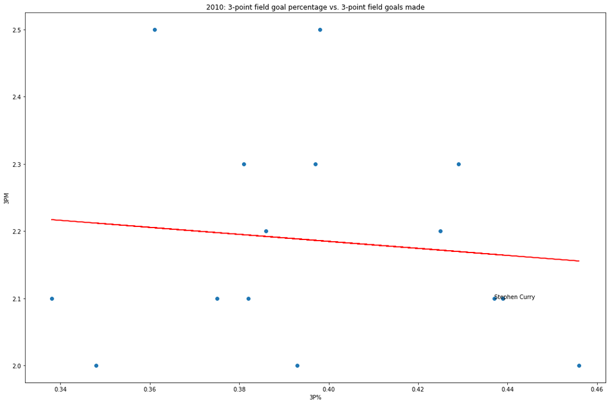

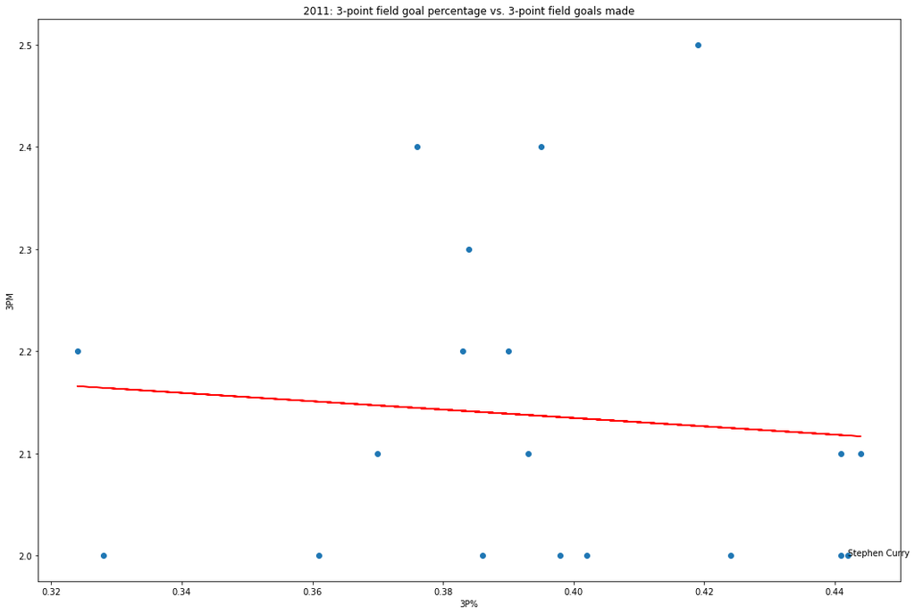

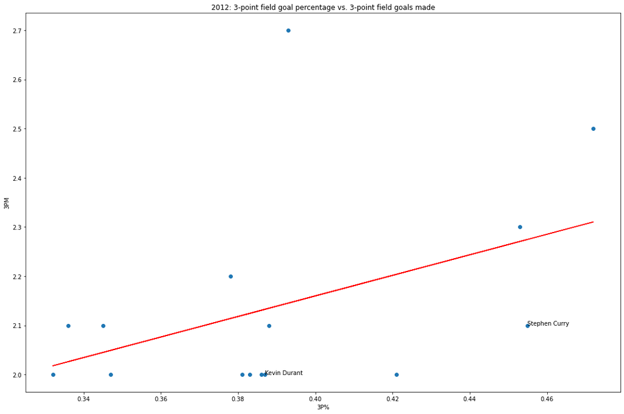

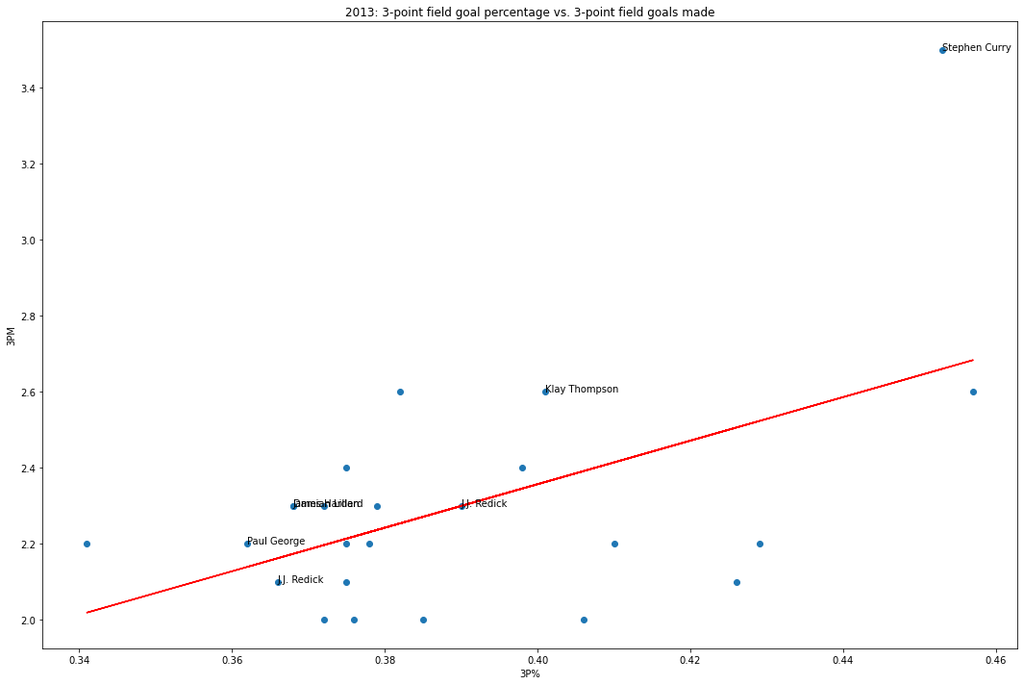

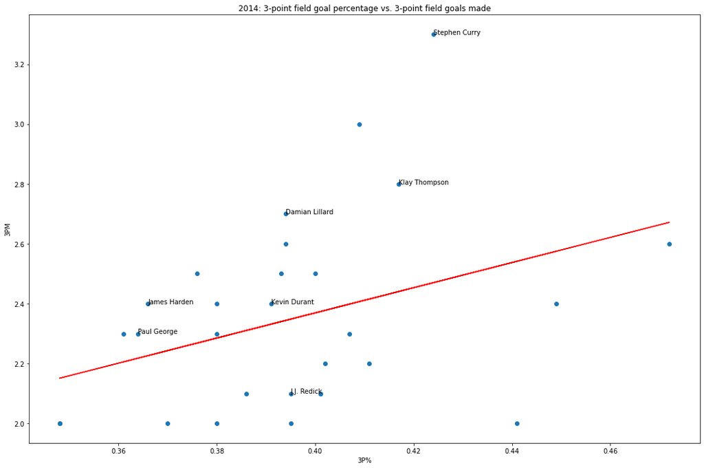

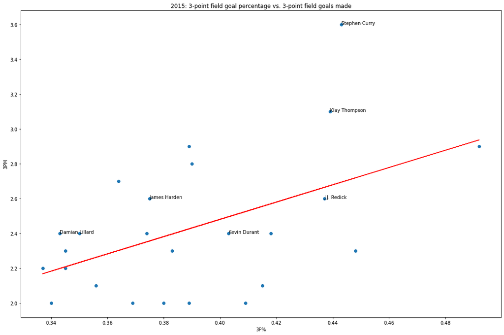

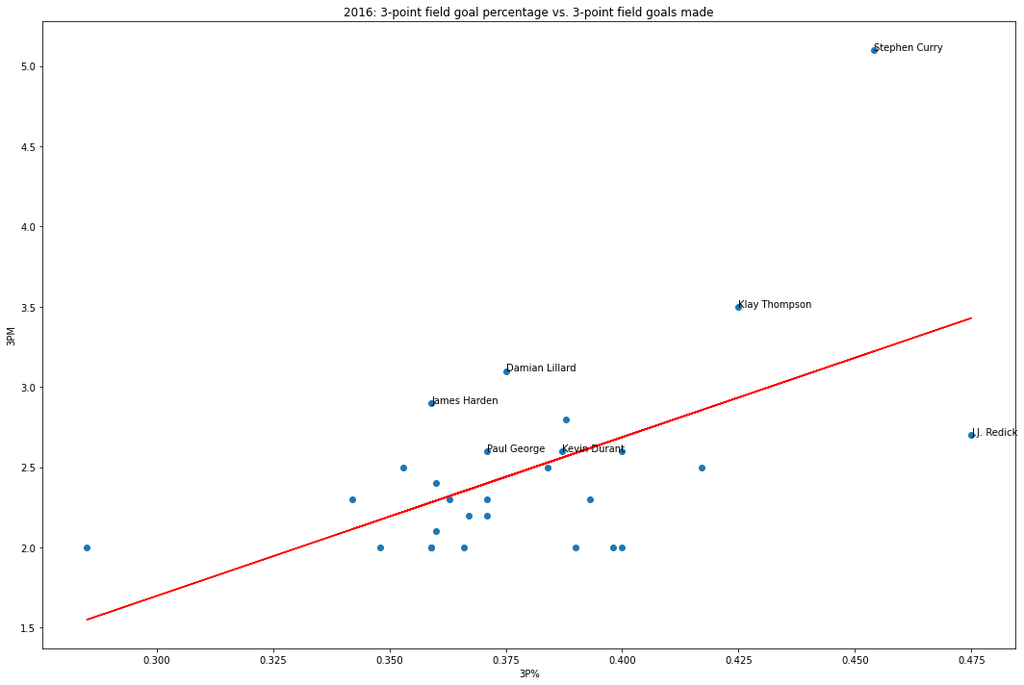

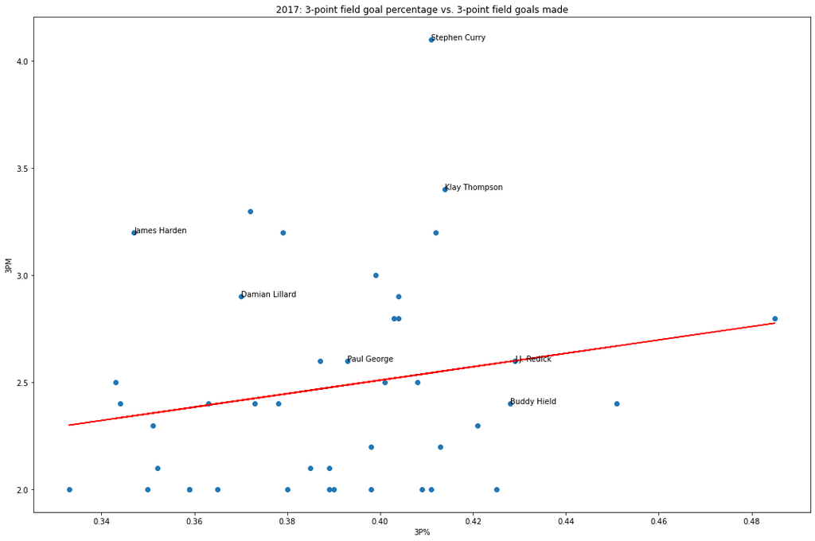

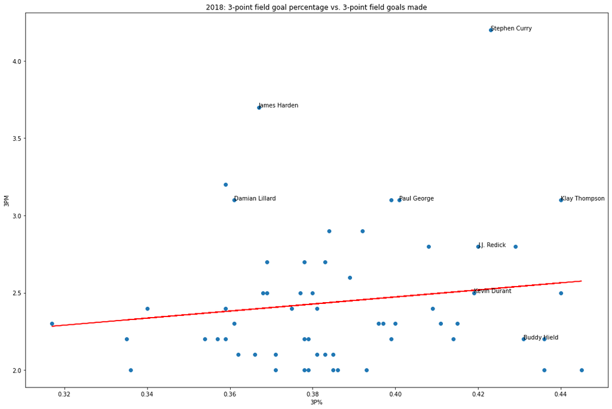

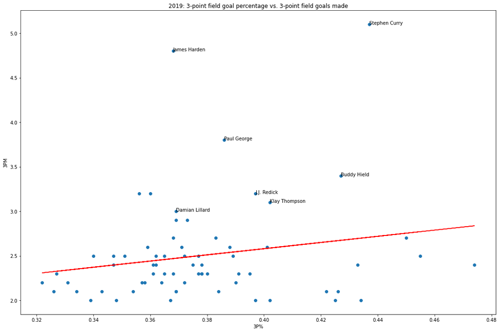

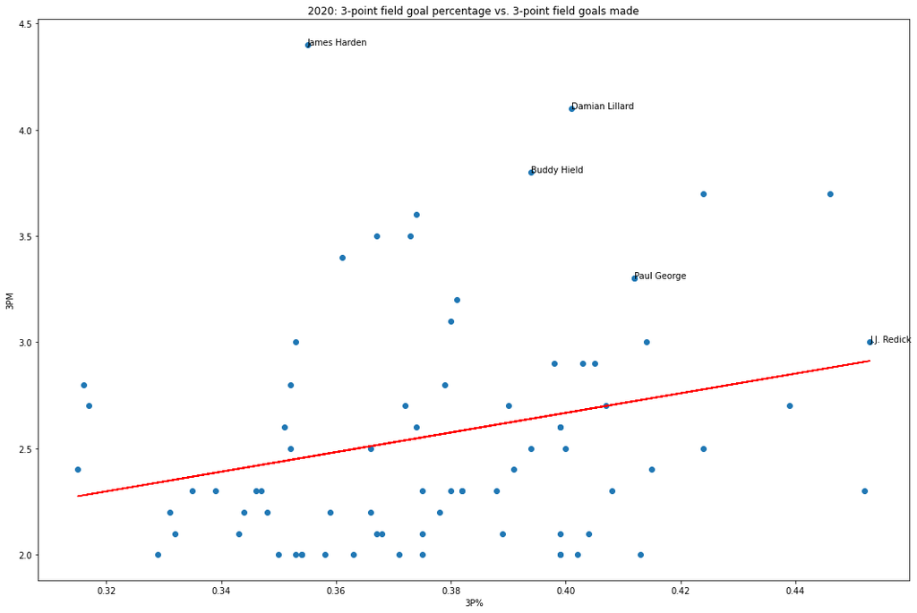

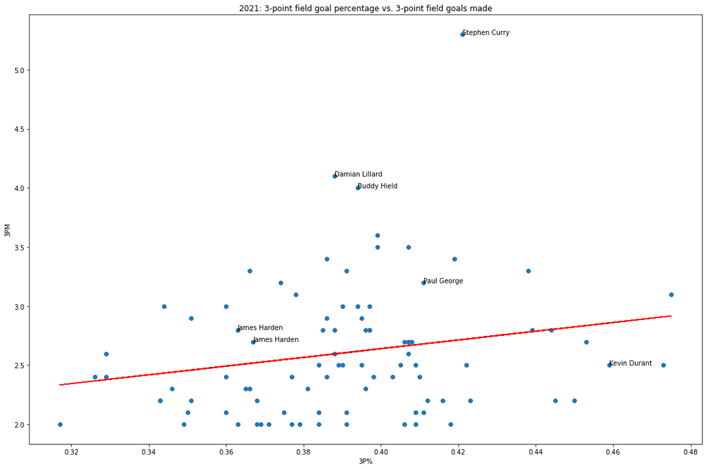

```python
#going through all nba season that Stephen Curry has played
#putting all players who made more than 2 threes per game in that season and played more than a quarter of the season (20 of 82 games (2011-2012 was a shortened season so there are less data points)) on a graph (3P% vs. 3PM) with the regresion line for the average of those players

#year for url and place to store table for that year
year = 2010
years_data = []

#loop through each url to get data
for i in range(12):

    #web scraping and placing data in table
    season = req.get("https://www.basketball-reference.com/leagues/NBA_" + str(year) + "_per_game.html")
    season_tables = pd.read_html(season.text, flavor='bs4')
    curr_table = season_tables[0]
    three_table = pd.DataFrame(columns=["Rk", "Player", "Season", "Age", "G", "3P", "3PA", "3P%", "PTS"])

    #remove edge case
    curr_table = curr_table.replace("3P", "0")
    curr_table = curr_table.replace("3PA", "0")
    curr_table = curr_table.replace("3P%", "0")
    curr_table = curr_table.replace("PTS", "0")
    curr_table = curr_table.replace("G", "0")

    #create a better formatted table and add the data to that table
    for x, y in curr_table.iterrows():
        float_three = float(y['3P'])
        float_3percent = float(y['3P%'])
        float_3attempt = float(y['3PA'])
        float_points = float(y['PTS'])
        games = int(y['G'])
        if (float_three >= 2 and games >= 21):
            three_table.loc[len(three_table.index),
                            ["Rk", "Player", "Season", "Age", "G", "3P", "3PA", "3P%", "PTS"]] = [y["Rk"], y['Player'], year,
                                                                                             y['Age'], games, float_three, float_3attempt,
                                                                                             float_3percent, float_points]

    #regression line parameters
    three_table = three_table.sort_values(by='3P', ascending=False)
    list_3percent = [ [i] for i in three_table['3P%'].values]

    #print table
    print(three_table.head(10))
    print('\n')

    #reg line
    lm = linear_model.LinearRegression()
    eq = lm.fit(list_3percent, three_table['3P'].values)

    #plot data
    plt.figure(figsize=(15, 10))
    plt.scatter(three_table['3P%'], three_table['3P'], label=x)
    plt.plot(three_table['3P%'], lm.predict(list_3percent), color='red')
    plt.title(str(year) + ": 3-point field goal percentage vs. 3-point field goals made")
    plt.xlabel("3P%")
    plt.ylabel("3PM")

    #add table to list and go to next year
    years_data.append(three_table)
    year = year + 1

    #show specific popluar players' data points to compare to Curry through the years
    for i in range(three_table.shape[0]):
        if(three_table['Player'].tolist()[i] == "Stephen Curry" or three_table['Player'].tolist()[i] == "James Harden" or
           three_table['Player'].tolist()[i] == "Damian Lillard" or three_table['Player'].tolist()[i] == "J.J. Redick" or
           three_table['Player'].tolist()[i] == "Ray Allen" or three_table['Player'].tolist()[i] == "Klay Thompson" or
           three_table['Player'].tolist()[i] == "Kevin Durant" or three_table['Player'].tolist()[i] == "Jason Kidd" or
           three_table['Player'].tolist()[i] == "Paul George" or three_table['Player'].tolist()[i] == "Buddy Hield"):
            plt.annotate(three_table['Player'].tolist()[i], (three_table['3P%'].tolist()[i], three_table['3P'].tolist()[i]))
    plt.tight_layout()
```

As you can see during the first 3 season of Curry's career he only shot around 5 threes a game resulting in about 2 made three pointers a game. That is a 40% success rate. For reference, anything above 40% is an above average 3-point percentage (Curry has never had a season under 40% 3P%). Then due to many factors Curry started shooting more three and hasn't looked back since.

[figure not shown]

```python
#combine all data from last cell

#start by adding 1st table to a new table and appending on the rest
big_table = years_data[0]
for i in range(len(years_data)):
    big_table = big_table.append(years_data[i], ignore_index=True)

#linear regression
three_percent = [ [i] for i in big_table['3P%'].values]

lr = linear_model.LinearRegression()
equation = lr.fit(three_percent, big_table['3P'].values)

#plotting data values
plt.figure(figsize=(15, 10))
plt.scatter(big_table['3P%'], big_table['3P'], label=x)
plt.plot(big_table['3P%'], lr.predict(three_percent), color='red')
plt.title("3-point field goal percentage vs. 3-point field goals made from 2010 - 2021")
plt.xlabel("3P%")
plt.ylabel("3PM")

year = 2010
#show Steph Curry's data points
for i in range(big_table.shape[0]):
    if(big_table['Player'].tolist()[i] == "Stephen Curry"):
        plt.annotate(big_table['Player'].tolist()[i] + "\n" + str(year), (big_table['3P%'].tolist()[i], big_table['3P'].tolist()[i]))
        year = year + 1
plt.tight_layout()
```

Hopefully the graphs and tables above show how impressive Curry has been throughout his Career. To speak more on the increase in 3-pointers and to gain a better wholistic view of how Curry changed the NBA game we are going to look at 3-pointers made vs. 3-pointers attempted by each team each season Curry has been in the league. Then to sum it up we will take the league averages of the 3-pointers attempted for that particular season for the duration of Curry's career (2010-2021).

For this table I had to switch sources because NBA references tables for teams was commented out in their HTML so I couldn't get the table correctly formatted. Instead I used ESPN (https://www.espn.com/). This site is public and has a lot of data on any popular sport. I'm going to be taking team seasonal statistics for each season Curry has been in the league.

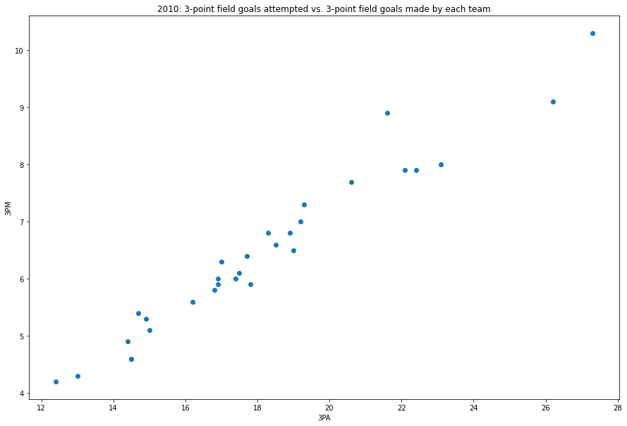

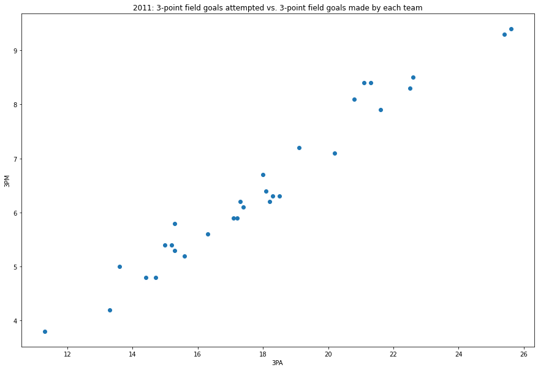

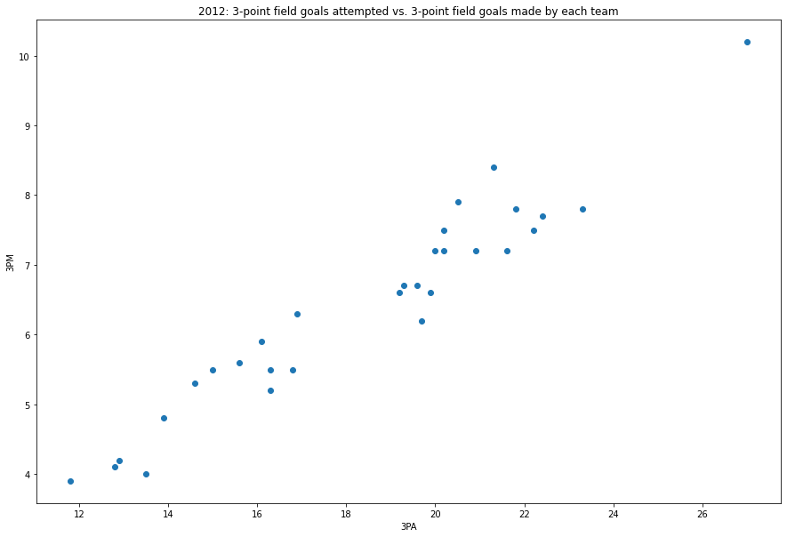

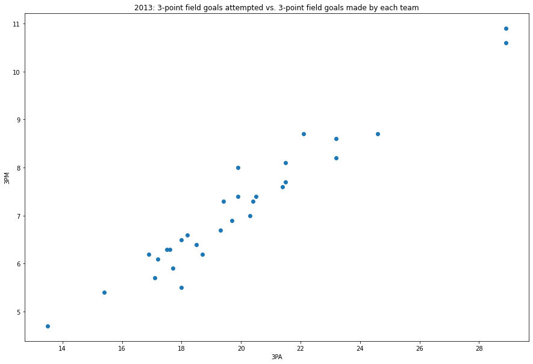

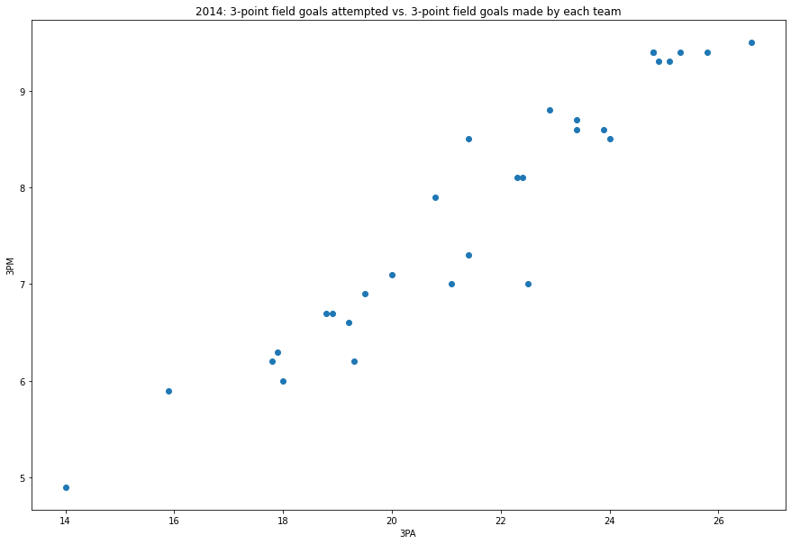

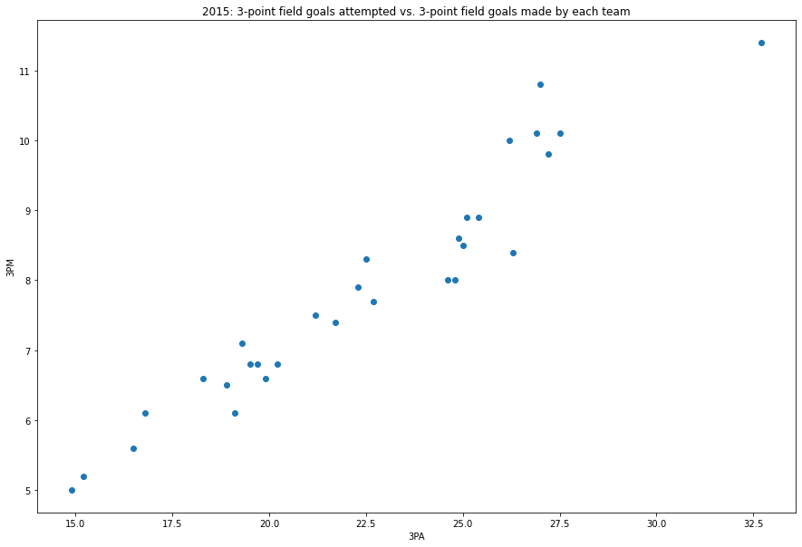

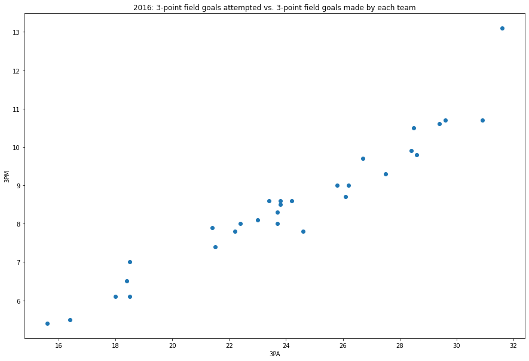

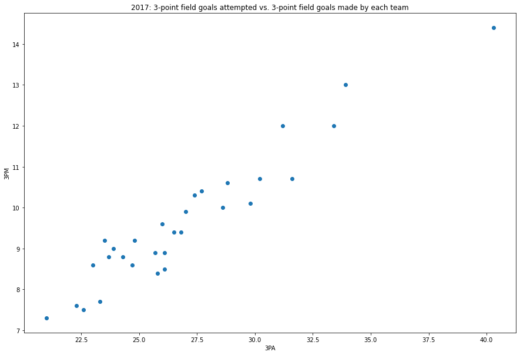

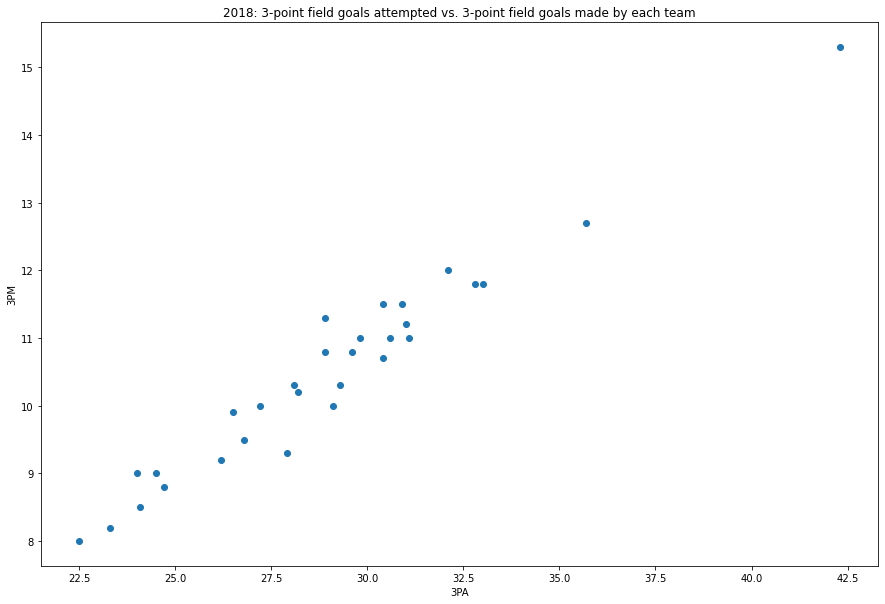

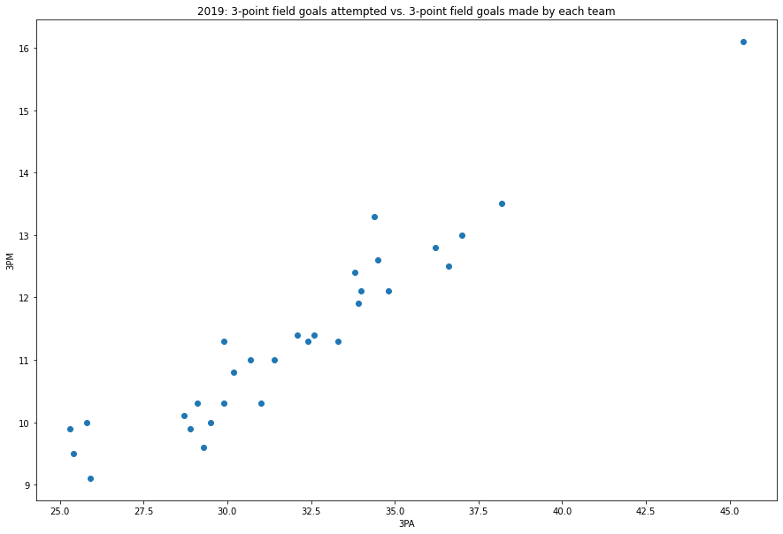

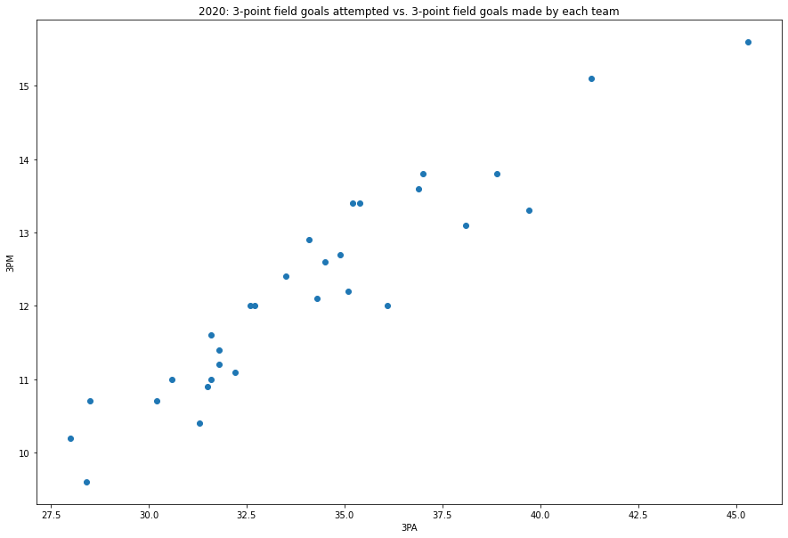

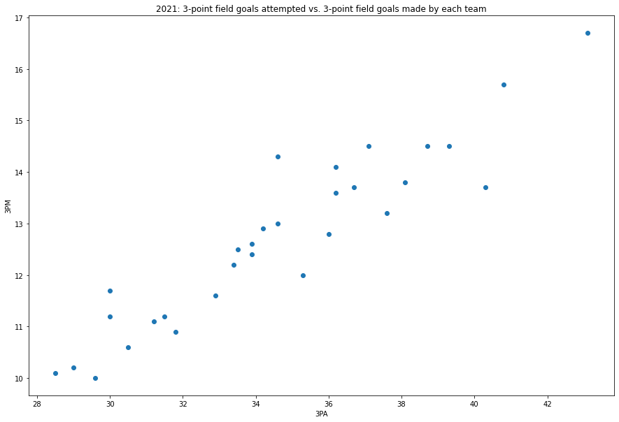

[1 more figures not shown]

```python
#year and averages list for each season
year = 2010
averages = []

#loop through season
for i in range(12):
    #web scraping and creating a dataframe
    team_stats = pd.DataFrame(columns=["Rk", "Team", "3P", "3PA", "3P%", "PTS"])
    teams = req.get("https://www.espn.com/nba/stats/team/_/season/" + str(year) + "/seasontype/2")
    teams_tables = pd.read_html(teams.text, flavor='bs4')
    stats = teams_tables[1]

    #getting average 3PA per season
    average = 0
    for x in range(30):
        average = stats['3PA'][x] + average
    average = average / 30
    averages.append(average)

    #plotting the 3PA and 3PM per season
    plt.figure(figsize=(15, 10))
    plt.scatter(stats['3PA'], stats['3PM'], label=x)
    plt.title(str(year) + ": 3-point field goals attempted vs. 3-point field goals made by each team")
    plt.xlabel("3PA")
    plt.ylabel("3PM")

    #going to next year
    year = year + 1

#plot averages of 3PA from 2010-2021
plt.figure(figsize=(15, 10))
plt.scatter([2010, 2011, 2012, 2013, 2014, 2015, 2016, 2017, 2018, 2019, 2020, 2021], averages, label=x)
plt.title("League average 3-point attempts per game from 2010 - 2021")
plt.xlabel("Year")
plt.ylabel("Average 3PA per game")
```

So as you can see there is a very linear relationship between the amount of 3-pointers a team attempts and the amount of 3-pointers they make. That would make a lot of sense logically. If you're good at shooting 3's take more 3's. Importantly, as the years go own you can see both the 3PA and 3PM increase. To paint a better picture of that I took the sum of all season WRT 3PA. In 2010 the league average 3PA was around 18 3's a game. By 2021 the league average 3PA is just under 35 3PA a game. That is twice as many 3-pointers attempted as a league in just over a decade. Stephen Curry and his team's success showed other teams how you can win and all the other teams tried to copy what he was doing, except they weren't as good at it.

It's important to note that (based on the individual statisical data on Steph Curry) Steph Curry's breakout season was 2013. The exact time the NBA started to see a noticable increase in 3PA per game. The 3PA increased even faster in 2016-2021 because by 2016 the league had caught up to Curry and their playstyle and everyone else wanted to shoot just as many 3's (similar to the moneyball effect in baseball, the Oakland A's were an outlier for a while, but eventually the other teams copied them and took their strategy so they were less effective themselves). The interesting thing though is while teams have started copying Curry and his team's playstyle, he is still an outlier among the best 3-point shooters in the league (even in 2021, look at the graph again).

I hope my data and graphs show how not just how incredible a basketball player Stephen Curry is, but, more importantly, I hope my data showed how much Stephen Curry has changed the game. In just half a decade Curry's presence in the NBA resulted in an offensive explosion from the 3-point line. I understand Stephen Curry is not the only reason for the increase in three-pointers, but I agrue he is at least one of the most important reasons for the changes in the game, if not the most important.

So far in his carrer Curry has won 3 championships, has the record for almost every 3-point statistic in the NBA, and has been the driving catalyst for the way the NBA is played today. I'll leave you with this incredible stat: Games with 11 or more 3-pointers made: Stephen Curry - 12, everyone else in NBA history combined - 14. He's the only NBA player that can make you scream at your TV in disbelief because he does things no body else has ever seen before.

I've shown a lot about Steph Curry here. Unfortunately, I could only cover his skill as a 3-point shooter. It is very underrated how much better he makes his teammates and how he opens up the offense for his team because everyone is so focused on him. He has various other elite NBA skills. If you want more information on Stephen Curry and his impact on basketball I urge you to look at some of the resources linked below. Hope you enjoyed!

https://www.youtube.com/watch?v=bvTPxCOfjdE&ab_channel=ThinkingBasketball

https://www.basketball-reference.com/players/c/curryst01.html

https://www.youtube.com/watch?v=dfs1Lq-yP8A&ab_channel=TheRinger